# NBM2 TASK 2: LOGISTIC REGRESSION FOR PREDICTIVE MODELING

Student ID – 009412995 Student Name – Rishika Gottepally

# Part I: Research Question

A.1 Which patients are at high risk of Re-admission and which are the features most significant to this re-admission rate?

A.2 The organization will benefit from knowing which variables need to be addressed and improved for a patient and it will help in decision making to reduce the re-admission rate.

# Part II: Method Justification

B.1 The Response Variable is Binary (in our data set re-admission is Yes or No). /No Multicollinearity: None of the predictor variables are highly correlated with each other. /Independence: The observations are independent. /There is a Linear Relationship Between Explanatory Variables and the Logit of the Response Variable. /There are No Extreme Outliers.

B.2 IPython Jupyter notebook is used to perform the analysis.Python programming language has robust packages like pandas,numpy,matplotlib.pyplot,seaborn,scipy.stats,sklearn which would help in manuplating data with ease and scikit-learn provides a clean and consistent interface to tons of different models. It provides us with many options for each model, but also chooses sensible defaults.

B.3 Logistic regression is an appropriate technique to analyze the research question because our target variable "ReAdmis" is a binomial(yes or no). And we would like to identify the dependency of other indipendent variables ('Gender''Soft_drink','HighBlood','Stroke','Overweight','Arthritis','Diabetes','Hyperlipidemia',etc.) on re-admission rate of an individual patient.It will improve our understanding of increased probability of re-admission as we include or remove different independent variables & find out whether or not they have a positive or negative relationship to our target variable.

# Part III: Data Preparation

C.1 My data goals will start with reading the csv file into python using read_csv from pandas,naming the imported dataset as md_df,checking for any missing data and following approriate imputation methods(mean,median or mode),renaming variable names for better understanding,encoding categorical variables having (yes/no) values to binary (either 1 or 0).Generating dummies for other categorical variables with more than 2 unique values.

C.3 • Import original dataset to Python. • Rename columns/variables of survey to easily recognizable column names (ex: "Item1" to "Timely_admission"). • Remove the extra 'Unamed' column name from the data set • Get a description of dataframe, structure (columns & rows) & data types. • View summary statistics. • Drop less meaningful identifying (ex: "CaseOrder") & demographic columns (ex: Lat,Lng) from dataframe. • Check for records with missing data & impute missing data with meaningful measures of central tendency (mean, median or mode) or simply remove outliers that are several standard deviations above the mean. • Create dummy variables in order to encode categorical, yes/no data points into 1/0 numerical values. • Check unique values for Marital,Initial_admin,Complication_risk and generate dummies for these variables using pandas package. • View univariate & bivariate visualizations. • Prepared dataset will be extracted & provided as "md_prepared.csv"

```python
# Standard data science imports
import numpy as np
import pandas as pd
from pandas import Series, DataFrame
# Visualization libraries
import seaborn as sns
import matplotlib.pyplot as plt
%matplotlib inline
# Statistics packages
import pylab
from pylab import rcParams
import statsmodels.api as sm
import statistics
from scipy import stats
# Scikit-learn
import sklearn
from sklearn import preprocessing
from sklearn.linear_model import LinearRegression
from sklearn.model_selection import train_test_split
from sklearn import metrics
from sklearn.metrics import classification_report
from sklearn.metrics import accuracy_score
# Ignore Warning Code
import warnings
warnings.filterwarnings('ignore')
```

```python
# Load data set using Pandas package
md_df = pd.read_csv('medical_clean.csv')
# Rename last 8 survey columns for better description of variables
md_df.rename(columns =  {'Item1':'Timely_admission',
'Item2':'Timely_treatment',
'Item3':'Timely_visits',
'Item4':'Reliability',
'Item5':'Options',
'Item6':'Treatment_hours',
'Item7':'Courteous_staff',
'Item8':'Active_Listening'},
inplace=True)

#remove the extra 'Unamed' column name from the data set
md_df=md_df.drop(md_df.columns[0], axis = 1)
print(md_df)

#information about the data set
md_df.info()
```

```
      CaseOrder Customer_id                           Interaction  \
0             1     C412403  8cd49b13-f45a-4b47-a2bd-173ffa932c2f
1             2     Z919181  d2450b70-0337-4406-bdbb-bc1037f1734c
2             3     F995323  a2057123-abf5-4a2c-abad-8ffe33512562
3             4     A879973  1dec528d-eb34-4079-adce-0d7a40e82205
4             5     C544523  5885f56b-d6da-43a3-8760-83583af94266
...         ...         ...                                   ...
9995       9996     B863060  a25b594d-0328-486f-a9b9-0567eb0f9723
9996       9997     P712040  70711574-f7b1-4a17-b15f-48c54564b70f
9997       9998     R778890  1d79569d-8e0f-4180-a207-d67ee4527d26
9998       9999     E344109  f5a68e69-2a60-409b-a92f-ac0847b27db0
9999      10000     I569847  bc482c02-f8c9-4423-99de-3db5e62a18d5

                                   UID          City State        County  \
0     3a83ddb66e2ae73798bdf1d705dc0932           Eva    AL        Morgan
```

[output cut: 110 more lines]

```python
md_df.head()
```

|  | CaseOrder | Customer_id | Interaction | UID | City | State | County | Zip | Lat | Lng | ... | TotalCharge | Additional_charges | Timely_admission | Timely_treatment | Timely_visits | Reliability | Options | Treatment_hours | Courteous_staff | Active_Listening |
| --- | --- | --- | --- | --- | --- | --- | --- | --- | --- | --- | --- | --- | --- | --- | --- | --- | --- | --- | --- | --- | --- |
| 0 | 1 | C412403 | 8cd49b13-f45a-4b47-a2bd-173ffa932c2f | 3a83ddb66e2ae73798bdf1d705dc0932 | Eva | AL | Morgan | 35621 | 34.34960 | -86.72508 | ... | 3191.048774 | 17939.403420 | 3 | 3 | 2 | 2 | 4 | 3 | 3 | 4 |
| 1 | 2 | Z919181 | d2450b70-0337-4406-bdbb-bc1037f1734c | 176354c5eef714957d486009feabf195 | Marianna | FL | Jackson | 32446 | 30.84513 | -85.22907 | ... | 4214.905346 | 17612.998120 | 3 | 4 | 3 | 4 | 4 | 4 | 3 | 3 |
| 2 | 3 | F995323 | a2057123-abf5-4a2c-abad-8ffe33512562 | e19a0fa00aeda885b8a436757e889bc9 | Sioux Falls | SD | Minnehaha | 57110 | 43.54321 | -96.63772 | ... | 2177.586768 | 17505.192460 | 2 | 4 | 4 | 4 | 3 | 4 | 3 | 3 |
| 3 | 4 | A879973 | 1dec528d-eb34-4079-adce-0d7a40e82205 | cd17d7b6d152cb6f23957346d11c3f07 | New Richland | MN | Waseca | 56072 | 43.89744 | -93.51479 | ... | 2465.118965 | 12993.437350 | 3 | 5 | 5 | 3 | 4 | 5 | 5 | 5 |
| 4 | 5 | C544523 | 5885f56b-d6da-43a3-8760-83583af94266 | d2f0425877b10ed6bb381f3e2579424a | West Point | VA | King William | 23181 | 37.59894 | -76.88958 | ... | 1885.655137 | 3716.525786 | 2 | 1 | 3 | 3 | 5 | 3 | 4 | 3 |

5 rows × 52 columns

```python
# Drop less meaningful identifying (ex: "CaseOrder") & demographic columns (ex: Lat,Lng) from dataframe.
md_df = md_df.drop(columns=['CaseOrder', 'Customer_id', 'Interaction', 'UID', 'City', 'State','Income',
       'County', 'Zip', 'Lat', 'Lng', 'Population', 'Area', 'Timezone', 'Job','Education','Employment','Services','VitD_levels'])
md_df.describe()
```

|  | Children | Age | Doc_visits | Full_meals_eaten | VitD_supp | Overweight | Anxiety | Initial_days | TotalCharge | Additional_charges | Timely_admission | Timely_treatment | Timely_visits | Reliability | Options | Treatment_hours | Courteous_staff | Active_Listening |
| --- | --- | --- | --- | --- | --- | --- | --- | --- | --- | --- | --- | --- | --- | --- | --- | --- | --- | --- |
| count | 10000.000000 | 10000.000000 | 10000.000000 | 10000.000000 | 10000.000000 | 10000.000000 | 10000.000000 | 10000.000000 | 10000.000000 | 10000.000000 | 10000.000000 | 10000.000000 | 10000.000000 | 10000.000000 | 10000.000000 | 10000.000000 | 10000.000000 | 10000.000000 |
| mean | 1.814000 | 53.295676 | 5.012200 | 1.001400 | 0.398900 | 0.737700 | 0.290600 | 30.901863 | 5891.538261 | 12934.528586 | 3.518800 | 3.506700 | 3.511100 | 3.515100 | 3.496900 | 3.522500 | 3.494000 | 3.509700 |
| std | 1.916969 | 17.993375 | 1.045734 | 1.008117 | 0.628505 | 0.439907 | 0.454062 | 26.899718 | 3377.558136 | 6542.601544 | 1.031966 | 1.034825 | 1.032755 | 1.036282 | 1.030192 | 1.032376 | 1.021405 | 1.042312 |
| min | 0.000000 | 18.000000 | 1.000000 | 0.000000 | 0.000000 | 0.000000 | 0.000000 | 1.001981 | 1256.751699 | 3125.702716 | 1.000000 | 1.000000 | 1.000000 | 1.000000 | 1.000000 | 1.000000 | 1.000000 | 1.000000 |
| 25% | 1.000000 | 41.000000 | 4.000000 | 0.000000 | 0.000000 | 0.000000 | 0.000000 | 5.419384 | 3253.239465 | 7986.487642 | 3.000000 | 3.000000 | 3.000000 | 3.000000 | 3.000000 | 3.000000 | 3.000000 | 3.000000 |
| 50% | 1.000000 | 53.295676 | 5.000000 | 1.000000 | 0.000000 | 1.000000 | 0.000000 | 17.015459 | 5852.250564 | 11573.979365 | 4.000000 | 3.000000 | 4.000000 | 4.000000 | 3.000000 | 4.000000 | 3.000000 | 3.000000 |
| 75% | 3.000000 | 65.000000 | 6.000000 | 2.000000 | 1.000000 | 1.000000 | 1.000000 | 59.459981 | 7614.989701 | 15626.491033 | 4.000000 | 4.000000 | 4.000000 | 4.000000 | 4.000000 | 4.000000 | 4.000000 | 4.000000 |
| max | 10.000000 | 89.000000 | 9.000000 | 7.000000 | 5.000000 | 1.000000 | 1.000000 | 71.981486 | 21524.224210 | 30566.073130 | 8.000000 | 7.000000 | 8.000000 | 7.000000 | 7.000000 | 7.000000 | 7.000000 | 7.000000 |

```python
#Create dummy variables in order to encode categorical, yes/no data points into 1/0 numerical values.
md_df['D.Gender'] = [1 if v == 'Male' else 0 for v in md_df['Gender']]
md_df['D.ReAdmis'] = [1 if v == 'Yes' else 0 for v in md_df['ReAdmis']]
md_df['D.Soft_drink'] = [1 if v == 'Yes' else 0 for v in md_df['Soft_drink']]
md_df['D.HighBlood'] = [1 if v == 'Yes' else 0 for v in md_df['HighBlood']]
md_df['D.Stroke'] = [1 if v == 'Yes' else 0 for v in md_df['Stroke']]
md_df['D.Overweight'] = [1 if v == 'Yes' else 0 for v in md_df['Overweight']]
md_df['D.Arthritis'] = [1 if v == 'Yes' else 0 for v in md_df['Arthritis']]
md_df['D.Diabetes'] = [1 if v == 'Yes' else 0 for v in md_df['Diabetes']]
md_df['D.Hyperlipidemia'] = [1 if v == 'Yes' else 0 for v in md_df['Hyperlipidemia']]
md_df['D.BackPain'] = [1 if v == 'Yes' else 0 for v in md_df['BackPain']]
md_df['D.Anxiety'] = [1 if v == 'Yes' else 0 for v in md_df['Anxiety']]
md_df['D.Allergic_rhinitis'] = [1 if v == 'Yes' else 0 for v in md_df['Allergic_rhinitis']]
md_df['D.Reflux_esophagitis'] = [1 if v == 'Yes' else 0 for v in md_df['Reflux_esophagitis']]
md_df['D.Asthma'] = [1 if v == 'Yes' else 0 for v in md_df['Asthma']]
```

```python
md_df['Marital'].unique()
```

```
array(['Divorced', 'Married', 'Widowed', 'Never Married', 'Separated'],
      dtype=object)
```

```python
md_df['Initial_admin'].unique()
```

```
array(['Emergency Admission', 'Elective Admission',
       'Observation Admission'], dtype=object)
```

```python
md_df['Complication_risk'].unique()
md_df['Initial_admin'].unique()
```

```
array(['Emergency Admission', 'Elective Admission',
       'Observation Admission'], dtype=object)
```

```python
md_df['D.Marital'] = [1 if v == 'Married' else 0 for v in md_df['Marital']]
Initial_admin=pd.get_dummies(md_df['Initial_admin'],drop_first=True)
Complication_risk=pd.get_dummies(md_df['Complication_risk'],drop_first=True)
md_df=pd.concat([md_df,Initial_admin,Complication_risk],axis=1)
md_df.info()
```

```
<class 'pandas.core.frame.DataFrame'>
RangeIndex: 10000 entries, 0 to 9999
Data columns (total 52 columns):
 #   Column                 Non-Null Count  Dtype
---  ------                 --------------  -----
 0   Children               10000 non-null  float64
 1   Age                    10000 non-null  float64
 2   Marital                10000 non-null  object
 3   Gender                 10000 non-null  object
 4   ReAdmis                10000 non-null  object
 5   Doc_visits             10000 non-null  int64
 6   Full_meals_eaten       10000 non-null  int64
 7   VitD_supp              10000 non-null  int64
 8   Soft_drink             10000 non-null  object
 9   Initial_admin          10000 non-null  object
```

[output cut: 44 more lines]

```python
Initial_admin.head()
```

|  | Emergency Admission | Observation Admission |
| --- | --- | --- |
| 0 | 1 | 0 |
| 1 | 1 | 0 |
| 2 | 0 | 0 |
| 3 | 0 | 0 |
| 4 | 0 | 0 |

```python
# Drop original categorical features from dataframe
md_df = md_df.drop(columns=['Gender','ReAdmis','Soft_drink','HighBlood','Stroke','Overweight','Arthritis','Diabetes',
                            'Hyperlipidemia',
                           'BackPain','Anxiety','Allergic_rhinitis','Reflux_esophagitis','Asthma','Marital','Initial_admin','Complication_risk'])
```

```python
md_df.info()
```

```
<class 'pandas.core.frame.DataFrame'>
RangeIndex: 10000 entries, 0 to 9999
Data columns (total 35 columns):
 #   Column                 Non-Null Count  Dtype
---  ------                 --------------  -----
 0   Children               10000 non-null  float64
 1   Age                    10000 non-null  float64
 2   Doc_visits             10000 non-null  int64
 3   Full_meals_eaten       10000 non-null  int64
 4   VitD_supp              10000 non-null  int64
 5   Initial_days           10000 non-null  float64
 6   TotalCharge            10000 non-null  float64
 7   Additional_charges     10000 non-null  float64
 8   Timely_admission       10000 non-null  int64
 9   Timely_treatment       10000 non-null  int64
```

[output cut: 27 more lines]

```python
md_df.head()
md_df.select_dtypes(include="number").columns
```

```
Index(['Children', 'Age', 'Doc_visits', 'Full_meals_eaten', 'VitD_supp',
       'Initial_days', 'TotalCharge', 'Additional_charges', 'Timely_admission',
       'Timely_treatment', 'Timely_visits', 'Reliability', 'Options',
       'Treatment_hours', 'Courteous_staff', 'Active_Listening', 'D.Gender',
       'D.ReAdmis', 'D.Soft_drink', 'D.HighBlood', 'D.Stroke', 'D.Overweight',
       'D.Arthritis', 'D.Diabetes', 'D.Hyperlipidemia', 'D.BackPain',
       'D.Anxiety', 'D.Allergic_rhinitis', 'D.Reflux_esophagitis', 'D.Asthma',
       'D.Marital', 'Emergency Admission', 'Observation Admission', 'Low',
       'Medium'],
      dtype='object')
```

C.4 Creating Univariate statistics for all continous numeric variables and Bi-variate statistics containing target variable("D.ReAdmis")

[output not shown]

[figure not shown]

```python
md_df[['Children', 'Age', 'Doc_visits',
       'Full_meals_eaten', 'VitD_supp', 'Initial_days', 'TotalCharge',
       'Additional_charges', 'Timely_admission', 'Timely_treatment']].hist()
```

```
array([[<AxesSubplot:title={'center':'Timely_visits'}>,
        <AxesSubplot:title={'center':'Reliability'}>,
        <AxesSubplot:title={'center':'Options'}>],
       [<AxesSubplot:title={'center':'Treatment_hours'}>,
        <AxesSubplot:title={'center':'Courteous_staff'}>,
        <AxesSubplot:title={'center':'Active_Listening'}>],
       [<AxesSubplot:title={'center':'D.Gender'}>,
        <AxesSubplot:title={'center':'D.ReAdmis'}>,
        <AxesSubplot:title={'center':'D.Soft_drink'}>],
       [<AxesSubplot:title={'center':'D.HighBlood'}>,
        <AxesSubplot:title={'center':'D.Stroke'}>,
        <AxesSubplot:title={'center':'D.Overweight'}>]], dtype=object)
```

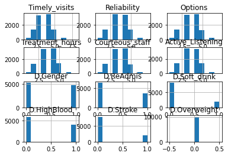

```python
md_df[['Timely_visits', 'Reliability', 'Options', 'Treatment_hours',
       'Courteous_staff', 'Active_Listening', 'D.Gender', 'D.ReAdmis',
       'D.Soft_drink', 'D.HighBlood', 'D.Stroke', 'D.Overweight']].hist()
```

```
array([[<AxesSubplot:title={'center':'D.Arthritis'}>,
        <AxesSubplot:title={'center':'D.Diabetes'}>,
        <AxesSubplot:title={'center':'D.Hyperlipidemia'}>,
        <AxesSubplot:title={'center':'D.BackPain'}>],
       [<AxesSubplot:title={'center':'D.Anxiety'}>,
        <AxesSubplot:title={'center':'D.Allergic_rhinitis'}>,
        <AxesSubplot:title={'center':'D.Reflux_esophagitis'}>,
        <AxesSubplot:title={'center':'D.Asthma'}>],
       [<AxesSubplot:title={'center':'D.Marital'}>,
        <AxesSubplot:title={'center':'Emergency Admission'}>,
        <AxesSubplot:title={'center':'Observation Admission'}>,
        <AxesSubplot:title={'center':'Low'}>],
       [<AxesSubplot:title={'center':'Medium'}>, <AxesSubplot:>,
        <AxesSubplot:>, <AxesSubplot:>]], dtype=object)
```

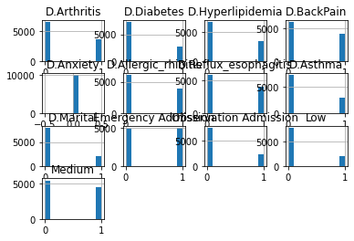

```python
md_df[['D.Arthritis', 'D.Diabetes', 'D.Hyperlipidemia', 'D.BackPain',
       'D.Anxiety', 'D.Allergic_rhinitis', 'D.Reflux_esophagitis', 'D.Asthma',
       'D.Marital', 'Emergency Admission', 'Observation Admission', 'Low',
       'Medium']].hist()
```

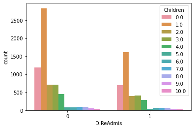

```python
#bivariate analysis
sns.countplot(x='D.ReAdmis',hue='Children',data=md_df)
'Children', 'Age', '', 'VitD_levels', 'Doc_visits',
       'Full_meals_eaten', 'VitD_supp', 'Initial_days', 'TotalCharge',
       'Additional_charges', 'Timely_admission', 'Timely_treatment',
       'Timely_visits', 'Reliability', 'Options', 'Treatment_hours',
       'Courteous_staff', 'Active_Listening', 'D.Gender', 'D.ReAdmis',
       'D.Soft_drink', 'D.HighBlood', 'D.Stroke', 'D.Overweight',
       'D.Arthritis', 'D.Diabetes', 'D.Hyperlipidemia', 'D.BackPain',
       'D.Anxiety', 'D.Allergic_rhinitis', 'D.Reflux_esophagitis', 'D.Asthma',
       'D.Marital', 'Emergency Admission', 'Observation Admission', 'Low',
       'Medium']
```

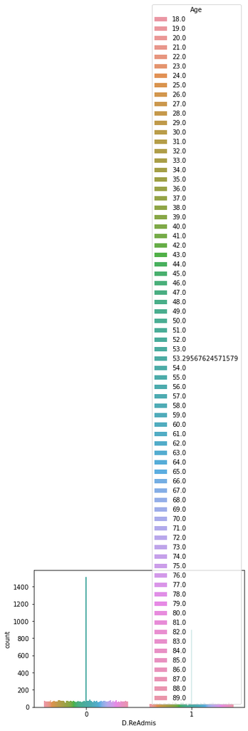

```python
sns.countplot(x='D.ReAdmis',hue='Age',data=md_df)
```

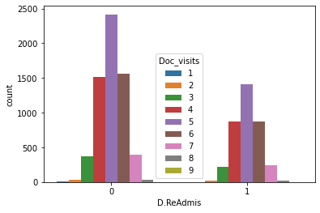

```python
sns.countplot(x='D.ReAdmis',hue='Doc_visits',data=md_df)
```

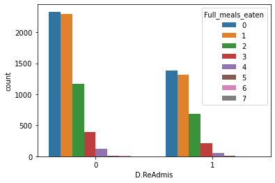

```python
sns.countplot(x='D.ReAdmis',hue='Full_meals_eaten',data=md_df)
```

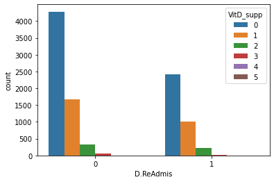

```python
sns.countplot(x='D.ReAdmis',hue='VitD_supp',data=md_df)
```

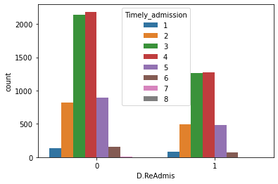

```python
sns.countplot(x='D.ReAdmis',hue='Timely_admission',data=md_df)
```

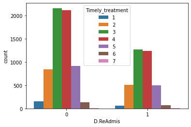

```python
sns.countplot(x='D.ReAdmis',hue='Timely_treatment',data=md_df)
```

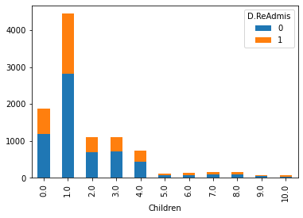

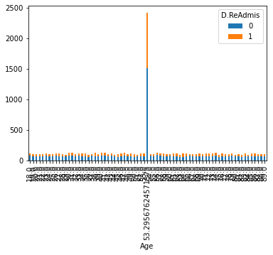

[figure not shown]

[figure not shown]

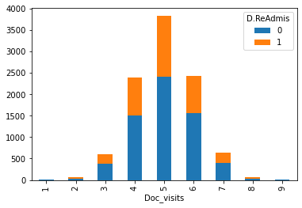

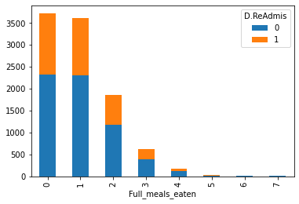

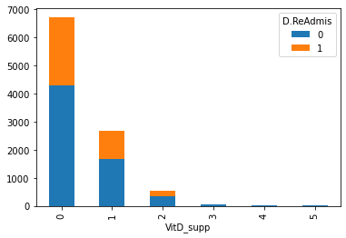

[figure not shown]

[figure not shown]

[figure not shown]

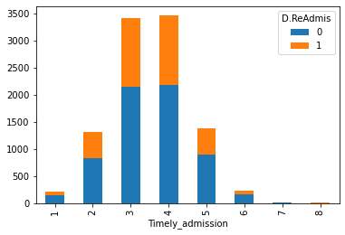

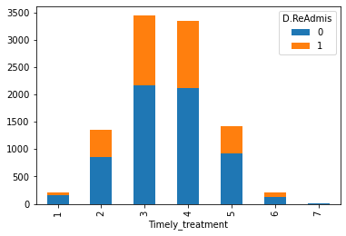

[24 more figures not shown]

```python
all_col =md_df[['Children', 'Age', 'Income', 'VitD_levels', 'Doc_visits',
       'Full_meals_eaten', 'VitD_supp', 'Initial_days', 'TotalCharge',
       'Additional_charges', 'Timely_admission', 'Timely_treatment',
       'Timely_visits', 'Reliability', 'Options', 'Treatment_hours',
       'Courteous_staff', 'Active_Listening', 'D.Gender', 'D.ReAdmis',
       'D.Soft_drink', 'D.HighBlood', 'D.Stroke', 'D.Overweight',
       'D.Arthritis', 'D.Diabetes', 'D.Hyperlipidemia', 'D.BackPain',
       'D.Anxiety', 'D.Allergic_rhinitis', 'D.Reflux_esophagitis', 'D.Asthma',
       'D.Marital', 'Emergency Admission', 'Observation Admission', 'Low',
       'Medium']]

target = md_df['D.ReAdmis']

def plot_stacked(c):
    md_df.groupby([c,target]).size().unstack().plot(kind='bar', stacked=True)

for c in all_col:
 if c!='D.ReAdmis':
    plot_stacked(c)
```

```python
# Extracting Prepared dataset
md_df.to_csv('md_prepared.csv')
md_df = pd.read_csv('md_prepared.csv')
```